# Debugging and condition handling

```r
library(tidyverse)
set.seed(1234)

theme_set(theme_minimal())
```

**Conditions** are a method for communicating to the user when something unanticipated has occurred. Helpfully, many package authors will build these into their functions to explicitly communicate with users when they attempt to use the function improperly. In fact, when you write your own functions you too can use conditions to alert users when something has gone wrong. There are three levels of conditions in R, which each lead to different outcomes.

# Types of conditions

## Fatal errors

**Fatal errors** are raised by `stop()` and force all execution to terminate. Typically errors are used to abort code or a function when it is impossible for the function to continue.

```r
addition <- function(x, y){
  if(!is_numeric(c(x, y))) stop("One of your inputs is not a number.")

  x + y
}

addition(3, "abc")
```

```
## Error in addition(3, "abc"): One of your inputs is not a number.
```

## Warnings

**Warnings** are generated by `warning()` and used to display potential problems. The function or code will continue to process, but the user will be notified that something undesirable has occurred. For example, the [**logit transformation**](https://en.wikipedia.org/wiki/Logit) converts a probability $p$ to the **log-odds**, or the logarithm of the odds. We can write a function to do this for us, but because probability values must be between 0 and 1, it will fail when $x$ is outside of the range $[0,1]$.

```r
logit <- function(x){
  log(x / (1 - x))
}

logit(-1)
```

```
## Warning in log(x/(1 - x)): NaNs produced
```

```
## [1] NaN
```

The result of `logit(-1)` is `NaN`.[^1] But the message produced is rather opaque. We could add a custom error message to stop the whole function:

```r
logit <- function(x){
 if(x < 0 | x > 1) stop('x not between 0 and 1')
 log(x / (1 - x))
}

logit(-1)
```

```
## Error in logit(-1): x not between 0 and 1
```

But what if instead we wanted to produce an `NA` value in these situations, and just warn the user what happened (but less cryptically)? We could revise this yet again to produce a warning message:

```r
logit <- function(x){
  x <- if_else(x < 0 | x > 1, NA_real_, x)
  if(is.na(x)) warning('x not between 0 and 1')
  log(x / (1 - x))
}

logit(-1)
```

```
## Warning in logit(-1): x not between 0 and 1
```

```
## [1] NA
```

## Messages

Messages are generated by `message()` and are used to give informative output to the user. It doesn’t mean anything even went wrong, just that there is some information that might prove useful. You’ve seen these before in `ggplot()` when generating smoothing lines.

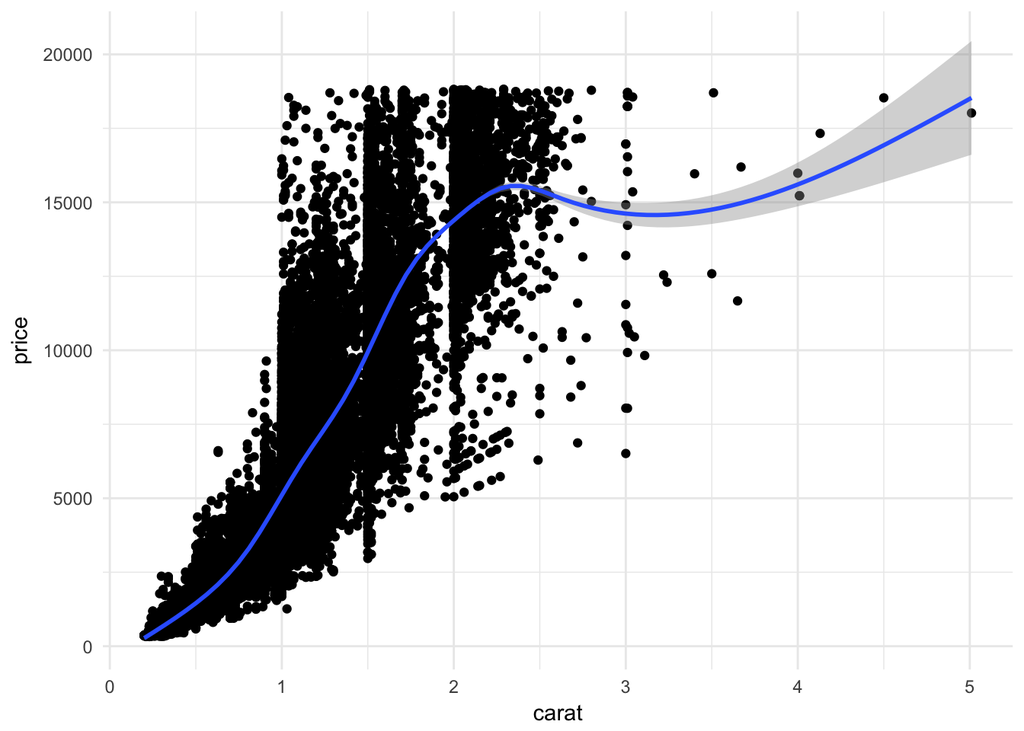

```r
ggplot(diamonds, aes(carat, price)) +
  geom_point() +
  geom_smooth()
```

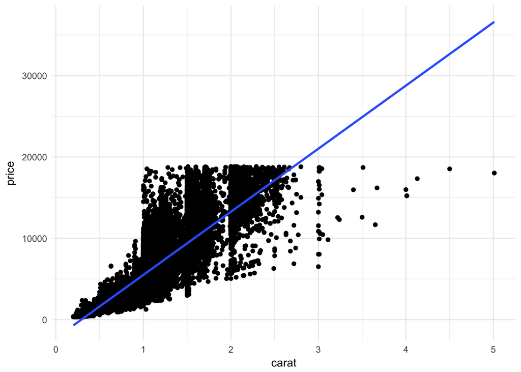

```r
ggplot(diamonds, aes(carat, price)) +
  geom_point() +
  geom_smooth(method = "lm")
```

The nice thing about messages is that they can be suppressed using the `suppressMessages()` function. This way if your function produces dozens or hundreds of messages, you can block them from being printed. A nice feature if you are knitting an R Markdown document. If you were to include messages simply by using the `print()` function, they could not be ignored.

```r
demo_message <- function() message("This is a message")
demo_message()
```

```
## This is a message
```

```r
suppressMessages(demo_message())  # no output

demo_print <- function() print("This is a message")
demo_print()
```

```
## [1] "This is a message"
```

```r
suppressMessages(demo_print())  # still output
```

```
## [1] "This is a message"
```

## Exercise: build a function with conditions

This is a basic function that calculates the square root of the sum of two numbers.

```r
sqrt_sum <- function(x, y){
  sqrt(sum(x, y))
}

sqrt_sum(3, 6)
```

```
## [1] 3
```

However, look at what happens when the sum of the numbers is negative.

```r
sqrt_sum(3, -6)
```

```
## [1] NaN
```

1. Rewrite `sqrt_sum()` to produce a fatal error any time the sum of the two numbers is negative.

   **Click for the solution**

   ```r
   sqrt_sum <- function(x, y){
     if(sum(x, y) < 0) stop("The sum of these numbers is negative.")
     sqrt(x + y)
   }

   sqrt_sum(3, -6)
   ```

   ```
   ## Error in sqrt_sum(3, -6): The sum of these numbers is negative.
   ```

2. Rewrite `sqrt_sum()` to return a missing value (`NA`) any time the sum of the two numbers is negative and produce a warning message explaining why this happened.

   **Click for the solution**

   ```r
   sqrt_sum <- function(x, y) {
     if(sum(x, y) < 0) {
       warning("The sum of these numbers is negative.")
       return(NA)
     }
     sqrt(x + y)
   }

   sqrt_sum(3,-6)
   ```

   ```
   ## Warning in sqrt_sum(3, -6): The sum of these numbers is negative.
   ```

   ```
   ## [1] NA
   ```

# Tracking down bugs using `traceback()`

Hadley writes a [detailed breakdown of all the debugging tools available in RStudio](http://adv-r.had.co.nz/Exceptions-Debugging.html#debugging-tools). Here I want to focus on one specific tool, the **traceback**.

## The call stack

The **call stack** is the sequence of calls that lead up to an error. Remember that when you execute a function in R, that function relies on additional functions to complete your task. In order to determine which function generated the bug, we need to “trace back” through the call stack to find the problematic function.

Here’s a trivial example from *Advanced R*. Note the sequence of functions:

- `f()` calls `g()`
- `g()` calls `h()`
- `h()` calls `i()`
- `i()` adds together a number and a string, creating an error

```r
f <- function(a) g(a)
g <- function(b) h(b)
h <- function(c) i(c)
i <- function(d) "a" + d
f(10)
```

```
## Error in "a" + d: non-numeric argument to binary operator
```

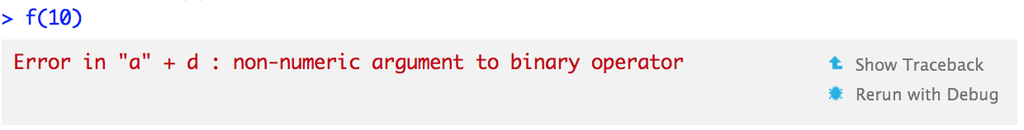

Output of `f(10)` in RStudio

Clearly the error is not generated by `f()`, yet at first glance all we know is that by executing `f()` we have generated an error. How could we view the call stack to determine the sequence of functions leading up to the error? By using RStudio, you see an option to “Show Traceback”. If you click on this option you should see the following:

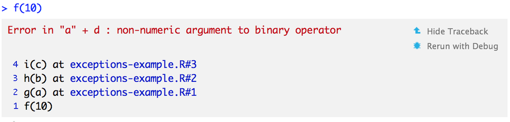

Traceback of `f(10)` in RStudio

Alternatively, run `traceback()` in the console:

```r
traceback()
```

```
# 4: i(c) at exceptions-example.R#3
# 3: h(b) at exceptions-example.R#2
# 2: g(a) at exceptions-example.R#1
# 1: f(10)
```

We read the call stack from bottom to top. The first call was `f(10)`, which calls `g()`, which calls `h()`, which calls `i()`, which triggers the error. If the code is saved in a file, R will also print the location where the function is saved using the format `filename.R#linenumber`. Now we know the actual error occurred in `i()`, so we would look at the body of this function to try and fix the problem.